# The Project

1. This is a project with minimal scaffolding. Expect to use the the discussion forums to gain insights! It’s not cheating to ask others for opinions or perspectives!
2. Be inquisitive, try out new things.
3. Use the previous modules for insights into how to complete the functions! You'll have to combine Pillow, OpenCV, and Pytesseract
4. There are hints provided in Coursera, feel free to explore the hints if needed. Each hint provide progressively more details on how to solve the issue. This project is intended to be comprehensive and difficult if you do it without the hints.

### The Assignment

Take a ZIP file) of images and process them, using a [library built into python](https://docs.python.org/3/library/zipfile.html) that you need to learn how to use. A ZIP file takes several different files and compresses them, thus saving space, into one single file. The files in the ZIP file we provide are newspaper images (like you saw in week 3). Your task is to write python code which allows one to search through the images looking for the occurrences of keywords and faces. E.g. if you search for "pizza" it will return a contact sheet of all of the faces which were located on the newspaper page which mentions "pizza". This will test your ability to learn a new ([library](https://docs.python.org/3/library/zipfile.html)), your ability to use OpenCV to detect faces, your ability to use tesseract to do optical character recognition, and your ability to use PIL to composite images together into contact sheets.

Each page of the newspapers is saved as a single PNG image in a file called images.zip. These newspapers are in english, and contain a variety of stories, advertisements and images. Note: This file is fairly large (~200 MB) and may take some time to work with, I would encourage you to use small_img.zip for testing.

Here's an example of the output expected. Using the small_img.zip file, if I search for the string "Christopher" I should see the following image:

[figure not shown]

If I were to use the images.zip file and search for "Mark" I should see the following image (note that there are times when there are no faces on a page, but a word is found!):

[figure not shown]

Note: That big file can take some time to process - for me it took nearly ten minutes! Use the small one for testing.

```
Enter a search word(small): Chris
Results found in file a-0.png
```

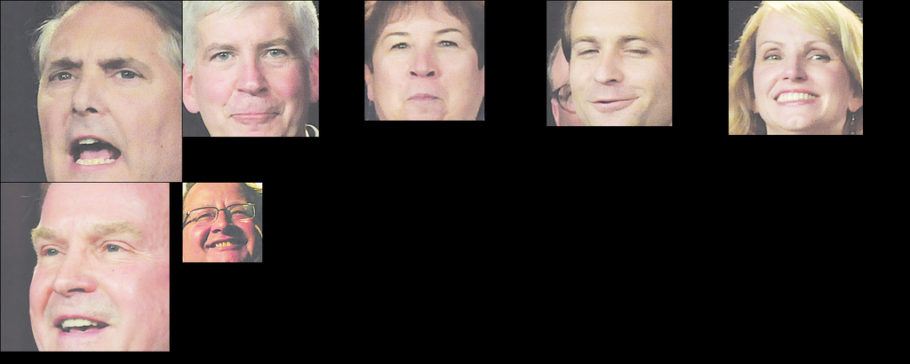

```
Results found in file a-3.png
```

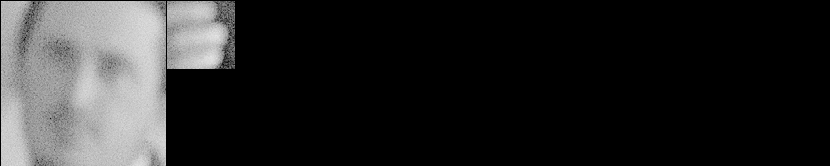

```
Enter a search word(large): Mark
Results found in file a-0.png
```

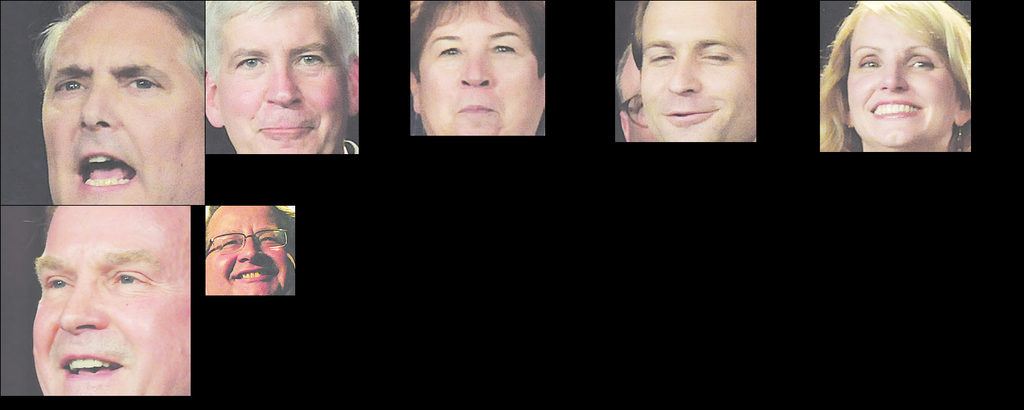

```
Results found in file a-1.png
```

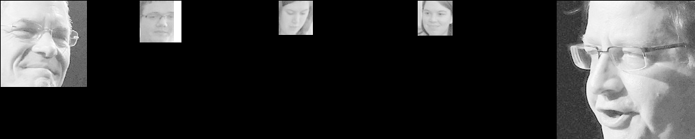

```
Results found in file a-10.png
But there were no faces in that file!
Results found in file a-13.png
```

```python
import zipfile

from PIL import Image
import pytesseract
import cv2 as cv
import numpy as np

# loading the face detection classifier
face_cascade = cv.CascadeClassifier('readonly/haarcascade_frontalface_default.xml')

# the rest is up to you!
# img_rgb=my_images[1].convert('RGB')
# display(img_rgb)

def get_pixel(image, i, j):
    # Inside image bounds?
    width, height = image.size
    if i > width or j > height:
      return None

    # Get Pixel
    pixel = image.getpixel((i, j))
    return pixel






#print("aa")

#pil_image = my_images[3].convert("RGB")
#open_cv_image = np.array(pil_image)
#print("aa")
#open_cv_image = open_cv_image[:, :, ::1].copy()
#print(open_cv_image)
#faces = face_cascade.detectMultiScale(open_cv_image, 1.15, minNeighbors = 7, minSize = (45,45))

#faces.tolist()

# Lets create a PIL image object
#pil_img=Image.fromarray(open_cv_image, mode="RGB")

from PIL import ImageDraw
# And lets create our drawing context
#drawing=ImageDraw.Draw(pil_img)
#print("aa")
# Now lets pull the rectangle out of the faces object

# Now we just draw a rectangle around the bounds
#prev_each = [0, 0, 0, 0]
#prev_each_2 = [0, 0, 0, 0]
#max_width = 0
#max_height = 0
#for each in faces.tolist():
#    if each[2] > max_width:
#        max_width = each[2]
#    if each[3] > max_height:
#        max_height = each[3]
#    each[2] = each[0] + each[2]
#    each[3] = each[1] + each[3]
#    print(each)
#    if (each[0] > prev_each[0]-50 and each[0] < prev_each[2]+50) and (each[1] > prev_each[1]-50 and each[1] < prev_each[3]+50) or (each[0] > prev_each_2[0]-50 and each[0] < prev_each_2[2]+50) and (each[1] > prev_each_2[1]-50 and each[1] < prev_each_2[3]+50) :
###        print("care")
##    else :
#        drawing.rectangle(each, outline="black")
#    prev_each_2 = prev_each
##    prev_each = each

# And display
#display(pil_img)

myzip = zipfile.ZipFile('readonly/small_img.zip')

my_images = []
names = []
for info in myzip.infolist():
    myfile = myzip.open(info)
    #print(myfile)
    names += [myfile.name]
    my_images.append((Image.open(myfile)))


count = 0
a = input("Enter a search word(small): ")
for each_image in my_images:
    pil_image = each_image.convert("RGB")
    open_cv_image = np.array(pil_image)
    open_cv_image = open_cv_image[:, :, ::1].copy()
    pil_img=Image.fromarray(open_cv_image, mode="RGB")
    text = pytesseract.image_to_string(pil_img)
    if a in text:
        print("Results found in file " + names[count])
        faces = face_cascade.detectMultiScale(open_cv_image, 1.20, minNeighbors = 7, minSize = (45,45))
        #print(faces)
        if len(faces) != 0:

            prev_each = [0, 0, 0, 0]
            prev_each_2 = [0, 0, 0, 0]
            max_width = 0
            max_height = 0
            each_listed = []
            for each in faces.tolist():
                if each[2] > max_width:
                    max_width = each[2]
                if each[3] > max_height:
                    max_height = each[3]
                each[2] = each[0] + each[2]
                each[3] = each[1] + each[3]
                #print(each)
                if (each[0] > prev_each[0]-50 and each[0] < prev_each[2]+50) and (each[1] > prev_each[1]-50 and each[1] < prev_each[3]+50) or (each[0] > prev_each_2[0]-50 and each[0] < prev_each_2[2]+50) and (each[1] > prev_each_2[1]-50 and each[1] < prev_each_2[3]+50) :
                    print("care")

                else :
                    drawing=ImageDraw.Draw(pil_img)
                    drawing.rectangle(each, outline="black")
                    each_listed += [each]
                prev_each_2 = prev_each
                prev_each = each


            x,y = 0,0
            i =(len(each_listed)-1)//5 + 1
            #print(i)
            for each_one in each_listed:
                [x0,y0,x1,y1]=each_one
                w,h = x1-x0, y1-y0
                white =(255, 255, 255)
                inew = Image.new('RGB',(w,h),white)
                #print(each_one)
                for irow in range(w):
                    for icol in range(h):
                        cech = get_pixel(pil_img,x0+irow,y0+icol)
                        inew.putpixel((irow,icol),cech)
                if (x == 0 and y == 0):
                    #print(max_width,max_height)
                    contact_sheet = Image.new(inew.mode,(max_width*5, max_height*i))
                contact_sheet.paste(inew,(x,y))
                if (x == (max_width*4)) and (i > 1):
                    x = 0
                    y += max_height
                else :
                    x += max_width
            display(contact_sheet)
        else :
            print("But there were no faces in that file!")
    #else :
        #print("There is no such word in that page")
    count += 1

myzip = zipfile.ZipFile('readonly/images.zip')

my_images = []
names = []
for info in myzip.infolist():
    myfile = myzip.open(info)
    #print(myfile)
    names += [myfile.name]
    my_images.append((Image.open(myfile)))

count = 0
b = input("Enter a search word(large): ")
for each_image in my_images:
    pil_image = each_image.convert("RGB")
    open_cv_image = np.array(pil_image)
    open_cv_image = open_cv_image[:, :, ::1].copy()
    pil_img=Image.fromarray(open_cv_image, mode="RGB")
    text = pytesseract.image_to_string(pil_img)
    if b in text:
        print("Results found in file " + names[count])
        faces = face_cascade.detectMultiScale(open_cv_image, 1.20, minNeighbors = 7, minSize = (45,45))
        #print(faces)
        if len(faces) != 0:

            prev_each = [0, 0, 0, 0]
            prev_each_2 = [0, 0, 0, 0]
            max_width = 0
            max_height = 0
            each_listed = []
            for each in faces.tolist():
                if each[2] > max_width:
                    max_width = each[2]
                if each[3] > max_height:
                    max_height = each[3]
                each[2] = each[0] + each[2]
                each[3] = each[1] + each[3]
                #print(each)
                if (each[0] > prev_each[0]-50 and each[0] < prev_each[2]+50) and (each[1] > prev_each[1]-50 and each[1] < prev_each[3]+50) or (each[0] > prev_each_2[0]-50 and each[0] < prev_each_2[2]+50) and (each[1] > prev_each_2[1]-50 and each[1] < prev_each_2[3]+50) :
                    print("care")

                else :
                    drawing=ImageDraw.Draw(pil_img)
                    drawing.rectangle(each, outline="black")
                    each_listed += [each]
                prev_each_2 = prev_each
                prev_each = each


            x,y = 0,0
            i =(len(each_listed)-1)//5 + 1
            #print(i)
            for each_one in each_listed:
                [x0,y0,x1,y1]=each_one
                w,h = x1-x0, y1-y0
                white =(255, 255, 255)
                inew = Image.new('RGB',(w,h),white)
                #print(each_one)
                for irow in range(w):
                    for icol in range(h):
                        cech = get_pixel(pil_img,x0+irow,y0+icol)
                        inew.putpixel((irow,icol),cech)
                if (x == 0 and y == 0):
                    #print(max_width,max_height)
                    contact_sheet = Image.new(inew.mode,(max_width*5, max_height*i))
                contact_sheet.paste(inew,(x,y))
                if (x == (max_width*4)) and (i > 1):
                    x = 0
                    y += max_height
                else :
                    x += max_width
            display(contact_sheet)
        else :
            print("But there were no faces in that file!")
    #else :
        #print("There is no such word in that page")
    count += 1



print("the search is completed")




#text = pytesseract.image_to_string(pil_img)
#print(text)



# Now lets bring in our drawing object



#x,y = 0,0
#i =len(faces.tolist())//5 + 1
#print(i)
#for each_one in faces.tolist():
#    [x0,y0,x1,y1]=each_one
#    w,h = x1, y1
#    white =(255, 255, 255)
#    inew = Image.new('RGB',(w,h),white)
#    print(each_one)
#    for irow in range(w):
#        for icol in range(h):
#            cech = get_pixel(pil_img,x0+irow,y0+icol)
#            inew.putpixel((irow,icol),cech)
#    if (x == 0 and y == 0):
#        print(max_width,max_height)
#        contact_sheet = Image.new(inew.mode,(max_width*5, max_height*i))
#    contact_sheet.paste(inew,(x,y))
#    if (x == (max_width*4)) and (i > 1):
#        x = 0
#        y += max_height
#    else :
#        x += max_width
```

[output not shown]